## GAPMINDER

#### 1. ENUNCIAT

**Nom:** Gapminder (Dades socio-econòmiques per països)

**Referència:** www.gapmider.org

**Descripció:** Aquesta plana web és un repositori de dades per països de molts àmbits. Per construir aquest conjunt de dades, s’han seleccionat uns quants indicadors. Es pretén modelitzar les relacions d’aquests indicadors (o transformacions dels mateixos) amb *l’esperança de vida del país*. Les dades corresponen a l’any 2005.

**Número de casos:** 165

L’objectiu serà construir un model lineal general per explicar la variable Esperança de vida (LifeExpectancy) dels països en base a la informació continguda en la base de dades. Serà important la correcció i interpretació del model obtingut.

**Indicacions:**

- Caldrà fer l’anàlisi exploratori preliminar per descriure les relacions observades
- S’han de tractar les dades faltants
- Si es poden millorar les relacions lineals o limitar l’efecte de dades influents, caldrà plantejar les transformacions que considereu adequades
- Considereu el Continent com a variable categòrica, però agrupeu en una mateixa categoria els continents d’Asia i Oceania.
- Al marge de la variable Continent, es poden considerar d’altres variables categòriques que puguin definirse a partir de categoritzar les numèriques
- S’han de tenir en compte possibles interaccions entre les variables categòriques i numèriques
- En la construcció del model, convé estudiar la presència de multicolinealitat i intentar reduir el seu efecte en el model per facilitar la interpretació
- Caldrà construir el model fent servir alguna tècnica per seleccionar les variables (eliminació de predictors no significatius, mecanismes stepwise o selecció dels millors models per selecció de variables)
- La validació del model s’ha de fer amb els gràfics i/o test oportuns per verificar les hipòtesis del model
- S’ha d’incloure l’estudi de dades atípiques i/o influents
- El model resultant ha de ser interpretat en terme de les relacions dels predictors seleccionats i el seu efecte sobre la variable resposta

#### 2. PREPARACIÓ DE LES DADES

Lectura del fitxer en format csv amb codificació amb coma decimal i separació amb punt i coma

```r
library(car)
library(effects)
Gapminder <- read.csv("Gapminder.csv", sep=";", dec=",")
```

Treiem la regió i posem el continent (variable categòrica) al final

```r
Gapminder=Gapminder[,c(1,4:22,3)]
```

Ajuntem Asia i Oceania per reduir les categories i perquè Oceania té pocs països (evitarem una categoria infrarepresentada)

```r
Gapminder[Gapminder$Continent=="OC","Continent"]="AS"
Gapminder$Continent=factor(Gapminder$Continent)
```

En el summary es veu que hi ha dades faltants d’alguns camps

```r
summary(Gapminder)
```

```
##           Pais     LifeExpectancy    Population           Surface
##  Afghanistan:  1   Min.   :43.97   Min.   :1.009e+05   Min.   :     340
##  Albania    :  1   1st Qu.:61.05   1st Qu.:3.323e+06   1st Qu.:   45230
##  Algeria    :  1   Median :71.50   Median :9.041e+06   Median :  199950
##  Angola     :  1   Mean   :67.76   Mean   :3.880e+07   Mean   :  799229
##  Argentina  :  1   3rd Qu.:75.10   3rd Qu.:2.728e+07   3rd Qu.:  603550
##  Armenia    :  1   Max.   :82.27   Max.   :1.308e+09   Max.   :17098240
##  (Other)    :159
##     AgrLand          Forest          PIBpc           AgrGDP
##  Min.   : 0.46   Min.   : 0.07   Min.   :  330   Min.   : 0.050
##  1st Qu.:23.40   1st Qu.:10.04   1st Qu.: 1975   1st Qu.: 3.728
##  Median :40.98   Median :28.43   Median : 5583   Median :10.135
##  Mean   :40.74   Mean   :29.54   Mean   :10970   Mean   :14.537
##  3rd Qu.:57.49   3rd Qu.:45.05   3rd Qu.:14085   3rd Qu.:22.010
##  Max.   :89.02   Max.   :94.72   Max.   :70014   Max.   :65.820
##  NA's   :1                                       NA's   :7
##   IndustryGDP     AlcohConsump       BadTeeth        SBPMale
##  Min.   : 7.89   Min.   : 0.020   Min.   :0.300   Min.   :122.4
##  1st Qu.:23.32   1st Qu.: 2.583   1st Qu.:1.140   1st Qu.:128.0
##  Median :28.73   Median : 6.080   Median :1.700   Median :130.7
##  Mean   :31.09   Mean   : 6.578   Mean   :2.077   Mean   :130.5
##  3rd Qu.:35.88   3rd Qu.: 9.777   3rd Qu.:2.900   3rd Qu.:133.0
##  Max.   :75.47   Max.   :18.220   Max.   :6.000   Max.   :138.1
##  NA's   :6       NA's   :1        NA's   :4
##      BMImen        BMIFemale     InternetUsers      Mobiles
##  Min.   :19.79   Min.   :20.13   Min.   : 0.07   Min.   :  0.28
##  1st Qu.:22.35   1st Qu.:23.42   1st Qu.: 2.85   1st Qu.: 10.46
##  Median :25.04   Median :25.67   Median : 8.22   Median : 35.20
##  Mean   :24.56   Mean   :25.35   Mean   :19.33   Mean   : 43.09
##  3rd Qu.:26.31   3rd Qu.:26.75   3rd Qu.:26.45   3rd Qu.: 72.65
##  Max.   :30.55   Max.   :33.58   Max.   :87.00   Max.   :127.51
##                                  NA's   :4       NA's   :1
##   DependRatio     ChildrenWomen       Births          CO2pc
##  Min.   : 26.09   Min.   :1.210   Min.   : 8.14   Min.   : 0.020
##  1st Qu.: 48.50   1st Qu.:1.790   1st Qu.:12.74   1st Qu.: 0.605
##  Median : 57.36   Median :2.480   Median :20.53   Median : 2.180
##  Mean   : 62.33   Mean   :2.977   Mean   :22.33   Mean   : 4.496
##  3rd Qu.: 76.66   3rd Qu.:3.790   3rd Qu.:29.11   3rd Qu.: 6.905
##  Max.   :108.10   Max.   :6.990   Max.   :47.82   Max.   :34.100
##                                                   NA's   :2
##  Continent
##  AF:46
##  AM:33
##  AS:47
##  EU:39
##
##
##
```

Seleccionem els casos complerts:

Ja que no podrem aplicar el mètode STEPWISE si tenim casos amb alguna variable amb dades faltants.

```r
Gapminder=na.omit(Gapminder) #Elimina tots els casos amb algún NA
```

Estudiem les relacions de les variables explicatives amb l’esperança de vida (var resposta):

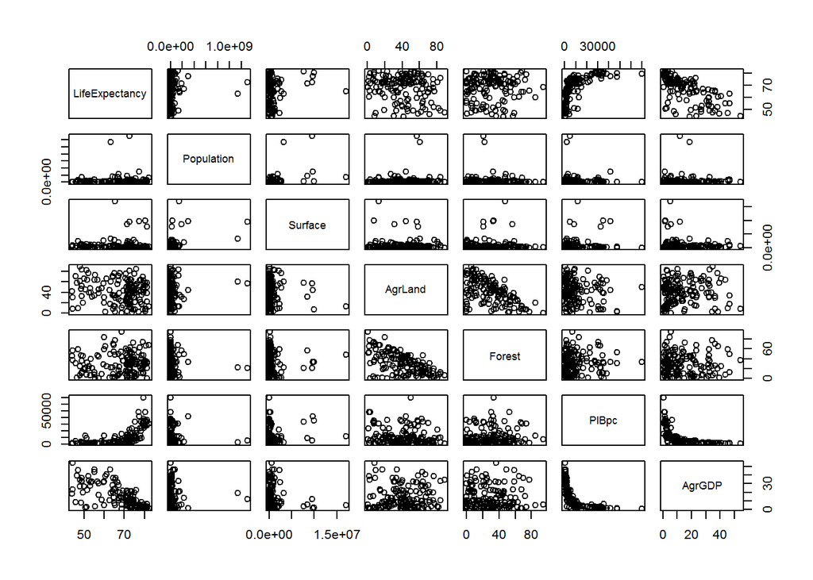

```r
pairs(Gapminder[,2:8]) #Tots no hi caben, s'ha de fer a trossos
```

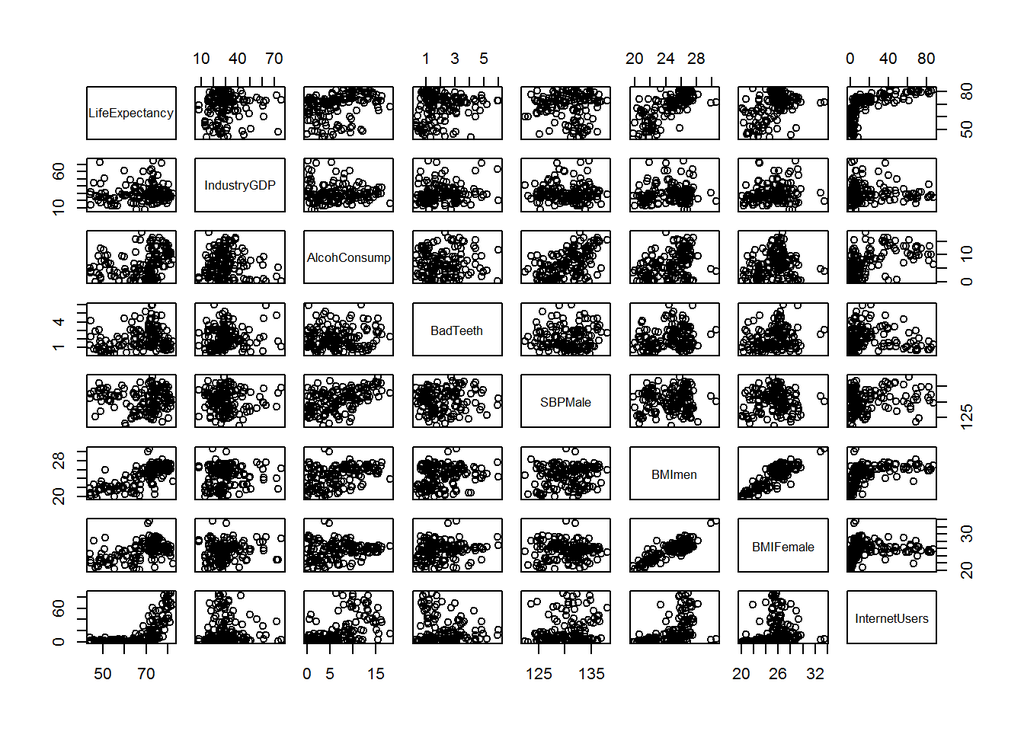

```r
pairs(Gapminder[,c(2,9:15)])
```

Mirem la primera linia (relacions amb LifeExpectancy), com que population i surface no sembla que sigui bona l’escala, haurem de prendre logaritmes per veure millor la relació.

La resposta (esperança de vida) té un rang força petit. No té massa sentit fer el logaritme perquè no canvia la mètrica Hi ha variables on la relació amb la resposta és clarament no lineal, afegim les variables transformades pel log

```r
Gapminder$lnPopulation=log(Gapminder$Population)
Gapminder$lnSurface=log(Gapminder$Surface)
Gapminder$lnPIBpc=log(Gapminder$PIBpc)
Gapminder$lnInternetUsers=log(Gapminder$InternetUsers)
Gapminder$lnMobiles=log(Gapminder$Mobiles)
Gapminder$lnCo2pc=log(Gapminder$CO2pc)
```

Li posem etiquetes a cada cas (el nom del pais)

```r
dades=Gapminder[,-c(1,21)]
row.names(dades)=Gapminder[,1]
```

2.2 Ajustem el model:

Mètode AIC: AIC=-2log versemblança + 2#par

Mètode BIC: BIC=-2log versemblança + log(n)#par

- Si utilitzem el mètode BIC step(… k=log(n)) ens quedara un mètode més simple perquè és un mètode més estricte: descatra tots aquells predictors amb … un valor de 10 o així.

```r
summary(m1 <- lm(LifeExpectancy ~ ., dades)) # MODEL COMPLET
```

```
##
## Call:
## lm(formula = LifeExpectancy ~ ., data = dades)
##
## Residuals:
##      Min       1Q   Median       3Q      Max
## -10.8387  -2.0527   0.3584   2.3559   8.6545
##
## Coefficients:
##                   Estimate Std. Error t value Pr(>|t|)
## (Intercept)      5.739e+01  2.491e+01   2.303 0.022974 *
## Population      -7.153e-10  2.760e-09  -0.259 0.795958
## Surface         -1.471e-07  2.160e-07  -0.681 0.497305
## AgrLand         -4.903e-02  2.103e-02  -2.331 0.021413 *
## Forest          -2.779e-02  1.981e-02  -1.403 0.163278
## PIBpc            8.409e-06  9.031e-05   0.093 0.925973
## AgrGDP           3.287e-02  6.505e-02   0.505 0.614264
## IndustryGDP     -2.896e-02  3.782e-02  -0.766 0.445384
## AlcohConsump    -3.762e-01  1.169e-01  -3.217 0.001663 **
## BadTeeth         5.562e-02  2.852e-01   0.195 0.845707
## SBPMale         -3.006e-01  1.282e-01  -2.345 0.020659 *
## BMImen           2.696e+00  4.494e-01   5.999 2.16e-08 ***
## BMIFemale       -1.441e+00  3.728e-01  -3.865 0.000181 ***
## InternetUsers    2.664e-03  4.176e-02   0.064 0.949233
## Mobiles         -5.846e-02  2.991e-02  -1.955 0.052957 .
## DependRatio      1.064e-01  7.223e-02   1.473 0.143251
## ChildrenWomen   -2.692e+00  1.400e+00  -1.922 0.056952 .
## Births          -2.956e-01  2.144e-01  -1.379 0.170456
## CO2pc           -1.638e-01  1.542e-01  -1.062 0.290222
## lnPopulation     7.096e-01  4.120e-01   1.722 0.087585 .
## lnSurface       -5.529e-01  3.349e-01  -1.651 0.101416
## lnPIBpc          3.208e+00  1.388e+00   2.311 0.022541 *
## lnInternetUsers  4.280e-01  5.900e-01   0.725 0.469562
## lnMobiles        1.291e+00  7.097e-01   1.818 0.071495 .
## lnCo2pc         -7.459e-01  7.951e-01  -0.938 0.350050
## ---
## Signif. codes:  0 '***' 0.001 '**' 0.01 '*' 0.05 '.' 0.1 ' ' 1
##
## Residual standard error: 3.668 on 120 degrees of freedom
## Multiple R-squared:  0.8909, Adjusted R-squared:  0.8691
## F-statistic: 40.82 on 24 and 120 DF,  p-value: < 2.2e-16
```

```r
summary(m2 <- step(m1, direction = "both", k=log(nrow(dades)))) # STEPWISE per BIC
```

```
## Start:  AIC=473.88
## LifeExpectancy ~ Population + Surface + AgrLand + Forest + PIBpc +
##     AgrGDP + IndustryGDP + AlcohConsump + BadTeeth + SBPMale +
##     BMImen + BMIFemale + InternetUsers + Mobiles + DependRatio +
##     ChildrenWomen + Births + CO2pc + lnPopulation + lnSurface +
##     lnPIBpc + lnInternetUsers + lnMobiles + lnCo2pc
##
##                   Df Sum of Sq    RSS    AIC
## - InternetUsers    1      0.05 1614.6 468.91
## - PIBpc            1      0.12 1614.7 468.91
## - BadTeeth         1      0.51 1615.0 468.95
## - Population       1      0.90 1615.4 468.98
## - AgrGDP           1      3.44 1618.0 469.21
## - Surface          1      6.24 1620.8 469.46
## - lnInternetUsers  1      7.08 1621.6 469.54
## - IndustryGDP      1      7.89 1622.4 469.61
## - lnCo2pc          1     11.84 1626.4 469.96
## - CO2pc            1     15.18 1629.7 470.26
## - Births           1     25.59 1640.1 471.18
## - Forest           1     26.47 1641.0 471.26
## - DependRatio      1     29.21 1643.7 471.50
## - lnSurface        1     36.66 1651.2 472.16
## - lnPopulation     1     39.91 1654.4 472.44
## - lnMobiles        1     44.49 1659.0 472.84
## - ChildrenWomen    1     49.71 1664.2 473.30
## - Mobiles          1     51.40 1665.9 473.45
## <none>                         1614.5 473.88
## - lnPIBpc          1     71.86 1686.4 475.21
## - AgrLand          1     73.12 1687.6 475.32
## - SBPMale          1     74.00 1688.5 475.40
## - AlcohConsump     1    139.28 1753.8 480.90
## - BMIFemale        1    200.98 1815.5 485.91
## - BMImen           1    484.19 2098.7 506.93
##
## Step:  AIC=468.91
## LifeExpectancy ~ Population + Surface + AgrLand + Forest + PIBpc +
##     AgrGDP + IndustryGDP + AlcohConsump + BadTeeth + SBPMale +
##     BMImen + BMIFemale + Mobiles + DependRatio + ChildrenWomen +
##     Births + CO2pc + lnPopulation + lnSurface + lnPIBpc + lnInternetUsers +
##     lnMobiles + lnCo2pc
```

[output cut: 499 more lines]

```
## + Births           1     12.31 1849.3 418.91
## + PIBpc            1     11.66 1850.0 418.96
## + Mobiles          1      0.74 1860.9 419.82
## + Forest           1      0.48 1861.1 419.84
## + Surface          1      0.12 1861.5 419.87
## + AgrGDP           1      0.01 1861.6 419.87
## + Population       1      0.00 1861.6 419.88
## + BadTeeth         1      0.00 1861.6 419.88
## - SBPMale          1    179.57 2041.2 423.27
## - AlcohConsump     1    206.52 2068.1 425.18
## - CO2pc            1    215.19 2076.8 425.78
## - lnPIBpc          1    374.31 2235.9 436.49
## - BMIFemale        1    553.12 2414.7 447.64
## - BMImen           1    889.26 2750.9 466.54
## - ChildrenWomen    1   1247.39 3109.0 484.29
```

```
##
## Call:
## lm(formula = LifeExpectancy ~ AlcohConsump + SBPMale + BMImen +
##     BMIFemale + ChildrenWomen + CO2pc + lnSurface + lnPIBpc,
##     data = dades)
##
## Residuals:
##      Min       1Q   Median       3Q      Max
## -12.5709  -2.1583   0.2231   2.2544   8.5614
##
## Coefficients:
##               Estimate Std. Error t value Pr(>|t|)
## (Intercept)   81.87718   15.88183   5.155 8.73e-07 ***
## AlcohConsump  -0.38498    0.09911  -3.884 0.000160 ***
## SBPMale       -0.40242    0.11111  -3.622 0.000412 ***
## BMImen         2.99675    0.37180   8.060 3.48e-13 ***
## BMIFemale     -1.72151    0.27082  -6.357 2.90e-09 ***
## ChildrenWomen -3.23824    0.33922  -9.546  < 2e-16 ***
## CO2pc         -0.35960    0.09070  -3.965 0.000118 ***
## lnSurface     -0.35658    0.15861  -2.248 0.026180 *
## lnPIBpc        3.09131    0.59116   5.229 6.27e-07 ***
## ---
## Signif. codes:  0 '***' 0.001 '**' 0.01 '*' 0.05 '.' 0.1 ' ' 1
##
## Residual standard error: 3.7 on 136 degrees of freedom
## Multiple R-squared:  0.8742, Adjusted R-squared:  0.8668
## F-statistic: 118.1 on 8 and 136 DF,  p-value: < 2.2e-16
```

INTERPRETACIÓ: Si AlcohConsump augmenta 1 unitat, això suposa un decrement de -0.38498 en l’esperança de vida, mantenint la resta constant (ceteris paribus)

Observem que BMImen i BMIfemale no tenen gaire sentit en quant a la relació amb l’esperança de vida (que no causalitat). Multicolineaitat entre ambdues????? -> vif

2.2.1 Validem el model que ens ha donat el mètode stepwise:

```r
Anova(m2,type=3)
```

```
## Anova Table (Type III tests)
##
## Response: LifeExpectancy
##                Sum Sq  Df F value    Pr(>F)
## (Intercept)    363.81   1 26.5781 8.734e-07 ***
## AlcohConsump   206.52   1 15.0873 0.0001596 ***
## SBPMale        179.57   1 13.1187 0.0004117 ***
## BMImen         889.26   1 64.9646 3.481e-13 ***
## BMIFemale      553.12   1 40.4079 2.896e-09 ***
## ChildrenWomen 1247.39   1 91.1278 < 2.2e-16 ***
## CO2pc          215.19   1 15.7203 0.0001181 ***
## lnSurface       69.18   1  5.0539 0.0261798 *
## lnPIBpc        374.31   1 27.3448 6.274e-07 ***
## Residuals     1861.62 136
## ---
## Signif. codes:  0 '***' 0.001 '**' 0.01 '*' 0.05 '.' 0.1 ' ' 1
```

2.2.2 Anàlisi de multicolinealitat del model 2

```r
vif(m2)
```

```
##  AlcohConsump       SBPMale        BMImen     BMIFemale ChildrenWomen
##      2.235258      1.545176      7.609880      4.504251      2.685525
##         CO2pc     lnSurface       lnPIBpc
##      2.340784      1.190603      5.526225
```

Veiem que PIB BMImen i BMI female, sobre tot el BMI dels dos gènere estan relacionades (oblidem el PIB). Quin dels dos predictors deixem en el model?

Ajustem el model amb una variable i amb l’altre (totes soles):

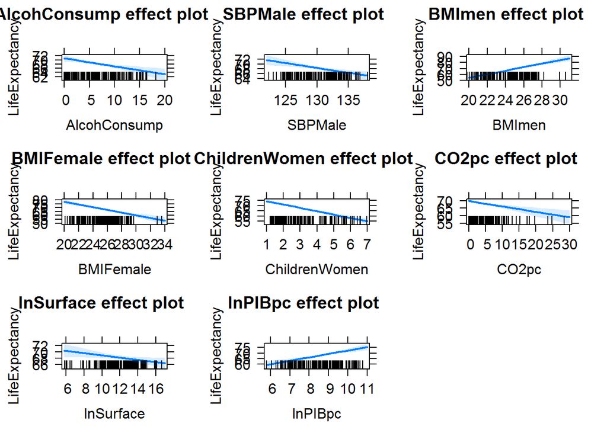

```r
plot(allEffects(m2))
```

```r
summary(m2a <- update(m2, .~.-BMImen))
```

```
##
## Call:
## lm(formula = LifeExpectancy ~ AlcohConsump + SBPMale + BMIFemale +
##     ChildrenWomen + CO2pc + lnSurface + lnPIBpc, data = dades)
##
## Residuals:
##      Min       1Q   Median       3Q      Max
## -19.7073  -1.9639   0.7765   2.6516  11.0600
##
## Coefficients:
##               Estimate Std. Error t value Pr(>|t|)
## (Intercept)    98.4496    19.0735   5.162 8.43e-07 ***
## AlcohConsump   -0.1919     0.1165  -1.647  0.10182
## SBPMale        -0.4329     0.1345  -3.219  0.00161 **
## BMIFemale       0.0634     0.1888   0.336  0.73754
## ChildrenWomen  -3.3764     0.4103  -8.229 1.32e-13 ***
## CO2pc          -0.2780     0.1092  -2.547  0.01198 *
## lnSurface      -0.3816     0.1921  -1.987  0.04894 *
## lnPIBpc         4.8139     0.6676   7.211 3.41e-11 ***
## ---
## Signif. codes:  0 '***' 0.001 '**' 0.01 '*' 0.05 '.' 0.1 ' ' 1
##
## Residual standard error: 4.481 on 137 degrees of freedom
## Multiple R-squared:  0.8141, Adjusted R-squared:  0.8046
## F-statistic:  85.7 on 7 and 137 DF,  p-value: < 2.2e-16
```

```r
summary(m2b <- update(m2, .~.-BMIFemale))
```

```
##
## Call:
## lm(formula = LifeExpectancy ~ AlcohConsump + SBPMale + BMImen +
##     ChildrenWomen + CO2pc + lnSurface + lnPIBpc, data = dades)
##
## Residuals:
##     Min      1Q  Median      3Q     Max
## -17.518  -1.525   0.667   2.388  11.579
##
## Coefficients:
##               Estimate Std. Error t value Pr(>|t|)
## (Intercept)    81.5806    18.0218   4.527 1.29e-05 ***
## AlcohConsump   -0.2063     0.1079  -1.913  0.05782 .
## SBPMale        -0.4173     0.1260  -3.311  0.00119 **
## BMImen          1.0641     0.2429   4.382 2.32e-05 ***
## ChildrenWomen  -3.3287     0.3846  -8.655 1.19e-14 ***
## CO2pc          -0.2885     0.1021  -2.825  0.00544 **
## lnSurface      -0.2392     0.1788  -1.338  0.18310
## lnPIBpc         3.4897     0.6670   5.232 6.15e-07 ***
## ---
## Signif. codes:  0 '***' 0.001 '**' 0.01 '*' 0.05 '.' 0.1 ' ' 1
##
## Residual standard error: 4.198 on 137 degrees of freedom
## Multiple R-squared:  0.8368, Adjusted R-squared:  0.8285
## F-statistic: 100.4 on 7 and 137 DF,  p-value: < 2.2e-16
```

Quin deixem? La que mantingui la màxima capacitat predictiva del model (R-squared)

La R^2 més gran la obtenim quan eliminem les dones (0.8368), a més, si eliminem els homes BMIFemale deixa de ser significativa. Com que lnSurface no és significatiu en el nou model, la treiem i tornem a fer el vif

```r
summary(m3 <- update(m2b, .~.-lnSurface))
```

```
##
## Call:
## lm(formula = LifeExpectancy ~ AlcohConsump + SBPMale + BMImen +
##     ChildrenWomen + CO2pc + lnPIBpc, data = dades)
##
## Residuals:
##     Min      1Q  Median      3Q     Max
## -18.032  -1.966   0.645   2.419  11.304
##
## Coefficients:
##               Estimate Std. Error t value Pr(>|t|)
## (Intercept)    71.9170    16.5586   4.343 2.70e-05 ***
## AlcohConsump   -0.2273     0.1070  -2.124  0.03545 *
## SBPMale        -0.3740     0.1222  -3.061  0.00265 **
## BMImen          1.1294     0.2386   4.733 5.41e-06 ***
## ChildrenWomen  -3.3905     0.3829  -8.855 3.67e-15 ***
## CO2pc          -0.3104     0.1011  -3.070  0.00258 **
## lnPIBpc         3.4846     0.6689   5.209 6.75e-07 ***
## ---
## Signif. codes:  0 '***' 0.001 '**' 0.01 '*' 0.05 '.' 0.1 ' ' 1
##
## Residual standard error: 4.21 on 138 degrees of freedom
## Multiple R-squared:  0.8347, Adjusted R-squared:  0.8275
## F-statistic: 116.1 on 6 and 138 DF,  p-value: < 2.2e-16
```

```r
vif(m3)
```

```
##  AlcohConsump       SBPMale        BMImen ChildrenWomen         CO2pc
##      2.012166      1.442756      2.419873      2.642147      2.245868
##       lnPIBpc
##      5.463926
```

Validem el model (les hipòtesis de variancia constant, normalitat dels residus etc.)

Estudi dels residus:

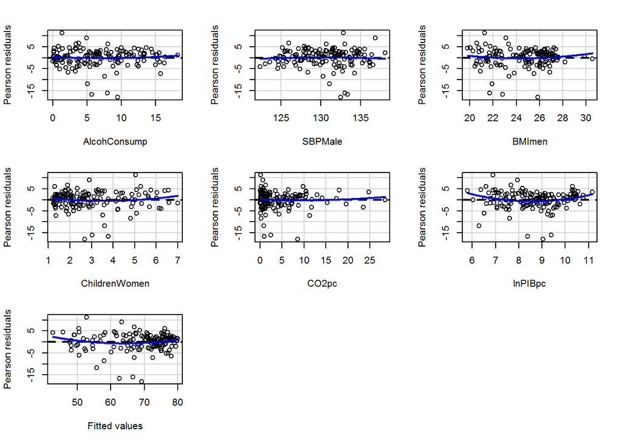

```
##               Test stat Pr(>|Test stat|)
## AlcohConsump     0.6738         0.501572
## SBPMale         -0.4263         0.670550
## BMImen           0.9952         0.321395
## ChildrenWomen    1.5191         0.131036
## CO2pc            0.7489         0.455224
## lnPIBpc          2.9657         0.003564 **
## Tukey test       1.8600         0.062890 .
## ---
## Signif. codes:  0 '***' 0.001 '**' 0.01 '*' 0.05 '.' 0.1 ' ' 1
```

```r
residualPlots(m3)
```

Els numeros ens indiquen si val la pena introduir el terme quadràtc (amb els pvalors). Així doncs, confirmem que una possible millora del model és la inclusió del PIB^2.

```r
summary(m4 <- update(m3,.~.+poly(lnPIBpc,2)-lnPIBpc))
```

```
##
## Call:
## lm(formula = LifeExpectancy ~ AlcohConsump + SBPMale + BMImen +
##     ChildrenWomen + CO2pc + poly(lnPIBpc, 2), data = dades)
##
## Residuals:
##      Min       1Q   Median       3Q      Max
## -16.4789  -1.5246   0.6344   2.3551  10.7404
##
## Coefficients:
##                   Estimate Std. Error t value Pr(>|t|)
## (Intercept)       100.4471    15.9805   6.286 4.07e-09 ***
## AlcohConsump       -0.2918     0.1064  -2.744  0.00689 **
## SBPMale            -0.3857     0.1189  -3.243  0.00148 **
## BMImen              1.3502     0.2438   5.539 1.51e-07 ***
## ChildrenWomen      -3.8034     0.3977  -9.564  < 2e-16 ***
## CO2pc              -0.4686     0.1119  -4.188 5.01e-05 ***
## poly(lnPIBpc, 2)1  50.2117     9.5815   5.240 5.91e-07 ***
## poly(lnPIBpc, 2)2  15.5382     5.2394   2.966  0.00356 **
## ---
## Signif. codes:  0 '***' 0.001 '**' 0.01 '*' 0.05 '.' 0.1 ' ' 1
##
## Residual standard error: 4.096 on 137 degrees of freedom
## Multiple R-squared:  0.8446, Adjusted R-squared:  0.8367
## F-statistic: 106.4 on 7 and 137 DF,  p-value: < 2.2e-16
```

poly(lnPIBpc,2) ja ens introdueix el terme lineal i el quadràtic (la paràbola), per tant no em surtira multicolinealitat i ens sobra ara el terme lineal del PIB,

Test de raó de versemblança (es pot fer perquè un model inclou l’altre).

```r
anova(m3,m4)
```

```
## Analysis of Variance Table
##
## Model 1: LifeExpectancy ~ AlcohConsump + SBPMale + BMImen + ChildrenWomen +
##     CO2pc + lnPIBpc
## Model 2: LifeExpectancy ~ AlcohConsump + SBPMale + BMImen + ChildrenWomen +
##     CO2pc + poly(lnPIBpc, 2)
##   Res.Df    RSS Df Sum of Sq      F   Pr(>F)
## 1    138 2446.3
## 2    137 2298.7  1    147.57 8.7952 0.003564 **
## ---
## Signif. codes:  0 '***' 0.001 '**' 0.01 '*' 0.05 '.' 0.1 ' ' 1
```

Gastant un grau de llibertat (de 138 a 137) hem reduit el RSS 140 i pico unitats. Veiem que el p valor és dignificatiu, per tant és millor. Si el pa valor fos major a 0.05, rebutjariem la inclusió del terme quadràtic (no val la pena gastar un grau de llibertat i ens quedariem amb el model més simple)

Comprovem que aquest canvi és una millora:

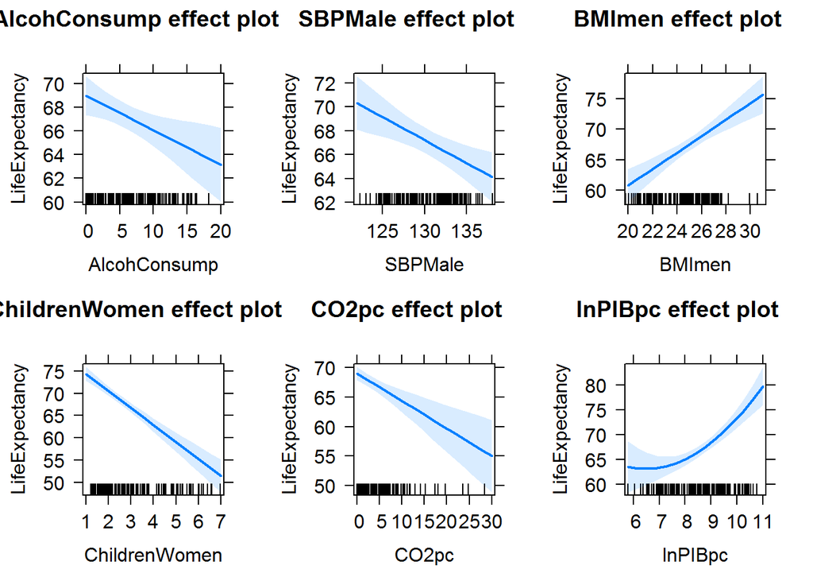

```r
plot(allEffects(m4))
```

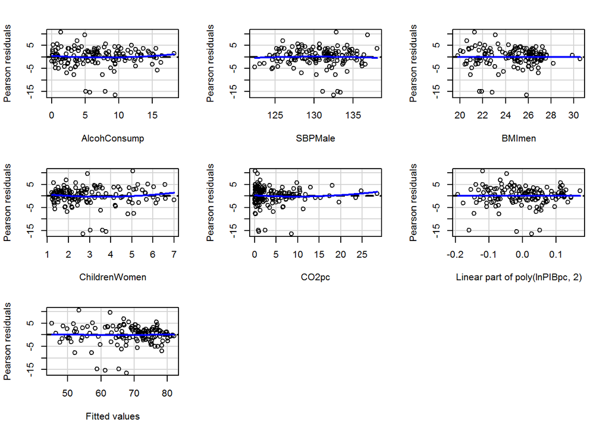

```
##                  Test stat Pr(>|Test stat|)
## AlcohConsump        0.8455           0.3993
## SBPMale            -0.3146           0.7535
## BMImen              0.0306           0.9756
## ChildrenWomen       1.1574           0.2491
## CO2pc               1.0374           0.3014
## poly(lnPIBpc, 2)
## Tukey test          0.2749           0.7834
```

```r
residualPlots(m4)
```

Interpretació PIB essent una paràbola: un increment petit en el PIB, l’esperança de vida pràcticament no canvia. En canvi, a partir de cert nivell de PIB, un increment unitari d’aquest, sí que suposa un gran increment en l’esperança de vida.

Anàlisi de normalitat dels residus:

```r
shapiro.test(resid(m4))
```

```
##
##  Shapiro-Wilk normality test
##
## data:  resid(m4)
## W = 0.89158, p-value = 7.103e-09
```

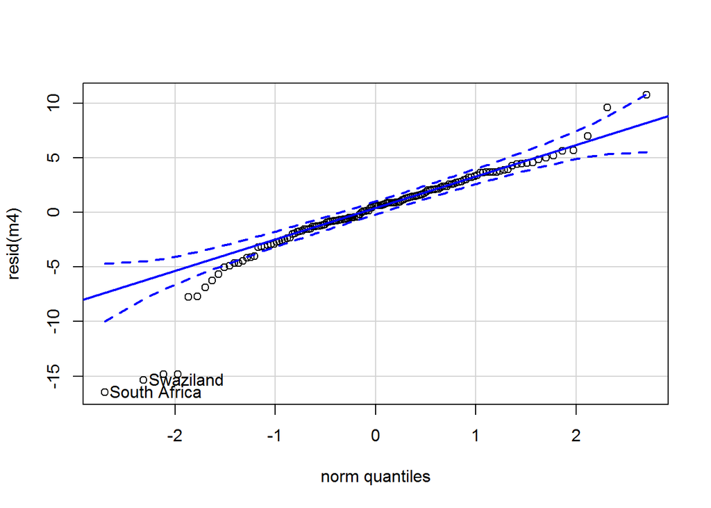

```
## South Africa    Swaziland
##          115          120
```

```r
qqPlot(resid(m4))
```

Veiem regions mal explicades i influents (sudÀfrica i Swazilàndia)

Ho comprovem:

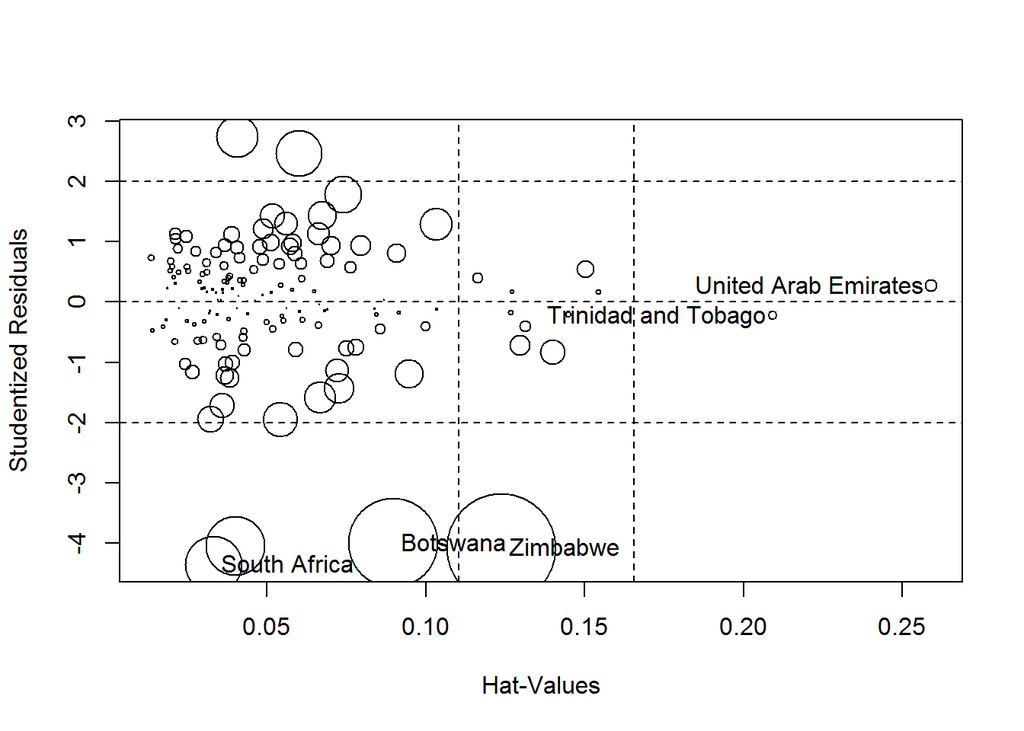

```
##                         StudRes        Hat       CookD
## Botswana             -4.0003330 0.08987287 0.178032072
## South Africa         -4.3512852 0.03332345 0.072142069
## Trinidad and Tobago  -0.2270087 0.20925243 0.001716505
## United Arab Emirates  0.2656042 0.25901664 0.003103527
## Zimbabwe             -4.0803370 0.12386443 0.264060564
```

```r
influencePlot(m4)
```

Obsrvacions vertaderament influencs: les de la taula. Leverage gran sí, pero a més distancia de cook gran.

El model sobreestima o infraestima l’esperança de vida d’aquestes obs? Al ser negatiu, el model sobreestima (residu negatiu, fórmula dels residus!!!), ens dona una esperança major de la que realment observem.

#### INCLOEM ARA LA VAR CATEGÒRICA (CONTINENTS)

Comencem de nou incloint la var categòrica a 4 nivells, i també les possibles interaccions entre la categòrica i les numèriques. Interaccions entre numèriques (continues) no les mirem.

Principi de marginalitat.Eliminem allò no significatiu encara que hi hagi una interacció significativa? O si hi ha interacció deixem diractament les dues variables?

```r
dades=Gapminder[,-c(1)] #Ara no treiem el continent
row.names(dades)=Gapminder[,1]
```

Model complet:

```r
summary(m5 <- lm(LifeExpectancy ~., dades))
```

```
##
## Call:
## lm(formula = LifeExpectancy ~ ., data = dades)
##
## Residuals:
##     Min      1Q  Median      3Q     Max
## -9.6183 -1.8821  0.2743  2.0642  9.3863
##
## Coefficients:
##                   Estimate Std. Error t value Pr(>|t|)
## (Intercept)      2.376e+01  2.524e+01   0.942 0.348365
## Population      -1.357e-09  2.639e-09  -0.514 0.608026
## Surface         -1.544e-07  2.064e-07  -0.748 0.455726
## AgrLand         -4.988e-02  2.008e-02  -2.484 0.014399 *
## Forest          -4.077e-02  1.903e-02  -2.142 0.034235 *
## PIBpc            8.688e-05  8.788e-05   0.989 0.324856
## AgrGDP           6.784e-02  6.330e-02   1.072 0.286008
## IndustryGDP     -2.605e-02  3.629e-02  -0.718 0.474224
## AlcohConsump    -4.276e-01  1.205e-01  -3.549 0.000558 ***
## BadTeeth        -1.611e-01  2.771e-01  -0.581 0.562040
## SBPMale          1.242e-02  1.443e-01   0.086 0.931553
## BMImen           2.457e+00  4.549e-01   5.400 3.55e-07 ***
## BMIFemale       -1.417e+00  3.715e-01  -3.815 0.000219 ***
## InternetUsers   -4.002e-03  3.957e-02  -0.101 0.919607
## Mobiles         -3.657e-02  2.969e-02  -1.232 0.220471
## DependRatio      7.745e-02  6.872e-02   1.127 0.262057
## ChildrenWomen   -1.824e+00  1.360e+00  -1.341 0.182421
## Births          -3.251e-01  2.107e-01  -1.543 0.125488
## CO2pc           -2.883e-01  1.517e-01  -1.900 0.059852 .
## ContinentAM      5.320e+00  1.453e+00   3.661 0.000379 ***
## ContinentAS      3.315e+00  1.241e+00   2.672 0.008623 **
## ContinentEU      1.614e+00  1.804e+00   0.895 0.372769
## lnPopulation     8.025e-01  3.917e-01   2.049 0.042735 *
## lnSurface       -4.855e-01  3.194e-01  -1.520 0.131183
## lnPIBpc          2.334e+00  1.341e+00   1.740 0.084418 .
## lnInternetUsers  4.145e-01  5.638e-01   0.735 0.463686
## lnMobiles        1.306e+00  6.722e-01   1.943 0.054453 .
## lnCo2pc         -1.732e-01  7.889e-01  -0.220 0.826593
## ---
## Signif. codes:  0 '***' 0.001 '**' 0.01 '*' 0.05 '.' 0.1 ' ' 1
##
## Residual standard error: 3.471 on 117 degrees of freedom
## Multiple R-squared:  0.9047, Adjusted R-squared:  0.8828
## F-statistic: 41.16 on 27 and 117 DF,  p-value: < 2.2e-16
```

Això només fa la variable resposta amb tota la resta però volem la interacció:

```r
summary(m5 <- lm(LifeExpectancy ~(.-Continent-BMIFemale)*Continent, dades))
```

```
##
## Call:
## lm(formula = LifeExpectancy ~ (. - Continent - BMIFemale) * Continent,
##     data = dades)
##
## Residuals:
##      Min       1Q   Median       3Q      Max
## -11.3161  -1.0861   0.0147   0.9024   9.4034
##
## Coefficients:
##                               Estimate Std. Error t value Pr(>|t|)
## (Intercept)                 -1.351e+02  9.112e+01  -1.483  0.14446
## Population                   9.712e-09  5.939e-08   0.164  0.87078
## Surface                      3.251e-06  2.534e-06   1.283  0.20555
## AgrLand                     -4.885e-02  5.871e-02  -0.832  0.40938
## Forest                      -9.780e-02  6.777e-02  -1.443  0.15537
## PIBpc                        9.626e-05  1.024e-03   0.094  0.92550
## AgrGDP                       9.905e-02  1.174e-01   0.843  0.40305
## IndustryGDP                 -1.573e-02  9.395e-02  -0.167  0.86775
## AlcohConsump                -1.210e+00  3.675e-01  -3.292  0.00185 **
## BadTeeth                     1.177e-02  1.100e+00   0.011  0.99150
## SBPMale                      8.743e-01  6.369e-01   1.373  0.17608
## BMImen                       2.447e+00  1.326e+00   1.845  0.07105 .
## InternetUsers               -4.222e-01  6.189e-01  -0.682  0.49833
## Mobiles                      2.021e-01  1.793e-01   1.127  0.26531
## DependRatio                 -5.416e-02  2.258e-01  -0.240  0.81141
## ChildrenWomen               -4.257e+00  3.589e+00  -1.186  0.24129
## Births                       5.638e-01  6.314e-01   0.893  0.37626
## CO2pc                       -2.023e+00  1.157e+00  -1.748  0.08671 .
## lnPopulation                 1.186e+00  1.735e+00   0.684  0.49739
## lnSurface                   -1.518e+00  1.090e+00  -1.393  0.17001
## lnPIBpc                      4.686e+00  3.944e+00   1.188  0.24043
## lnInternetUsers              3.065e+00  2.033e+00   1.508  0.13805
## lnMobiles                   -3.186e+00  2.718e+00  -1.172  0.24687
## lnCo2pc                     -1.307e+00  2.242e+00  -0.583  0.56260
## ContinentAM                  1.969e+02  1.786e+02   1.103  0.27546
## ContinentAS                  1.802e+02  1.116e+02   1.615  0.11271
## ContinentEU                  1.439e+02  1.396e+02   1.031  0.30776
## Population:ContinentAM      -6.102e-08  7.686e-08  -0.794  0.43107
## Population:ContinentAS      -1.148e-08  5.967e-08  -0.192  0.84816
```

[output cut: 58 more lines]

```
## ContinentAM:lnInternetUsers  2.294e+00  8.343e+00   0.275  0.78447
## ContinentAS:lnInternetUsers -2.376e+00  2.350e+00  -1.011  0.31697
## ContinentEU:lnInternetUsers -2.073e+00  5.019e+00  -0.413  0.68134
## ContinentAM:lnMobiles        1.583e+00  6.989e+00   0.226  0.82178
## ContinentAS:lnMobiles        2.579e+00  3.379e+00   0.763  0.44897
## ContinentEU:lnMobiles       -1.021e+01  2.794e+01  -0.365  0.71637
## ContinentAM:lnCo2pc         -1.533e+00  7.238e+00  -0.212  0.83316
## ContinentAS:lnCo2pc          9.109e-02  3.076e+00   0.030  0.97650
## ContinentEU:lnCo2pc          1.059e+01  1.274e+01   0.831  0.40976
## ---
## Signif. codes:  0 '***' 0.001 '**' 0.01 '*' 0.05 '.' 0.1 ' ' 1
##
## Residual standard error: 4.273 on 49 degrees of freedom
## Multiple R-squared:  0.9395, Adjusted R-squared:  0.8223
## F-statistic: 8.015 on 95 and 49 DF,  p-value: 6.393e-13
```

Hem de depurar el model, treure les vars no significatives. Ho fem automàticament amb STEPWISE (normalment)

```r
summary(m6 <- step(m5, direction="both", k=log(nrow(dades)), trace=0)) # trace=0, només ens treu el model amb el que es queda, també podem veure els dos darrers (trade=2) i així..
```

```
##
## Call:
## lm(formula = LifeExpectancy ~ PIBpc + AlcohConsump + BMImen +
##     ChildrenWomen + CO2pc + lnPopulation + lnSurface + lnPIBpc +
##     Continent + AlcohConsump:Continent, data = dades)
##
## Residuals:
##      Min       1Q   Median       3Q      Max
## -12.9719  -1.7164   0.2452   1.9397  11.2292
##
## Coefficients:
##                            Estimate Std. Error t value Pr(>|t|)
## (Intercept)               2.376e+01  7.981e+00   2.977 0.003468 **
## PIBpc                     2.146e-04  6.424e-05   3.341 0.001091 **
## AlcohConsump             -1.002e+00  1.696e-01  -5.908 2.86e-08 ***
## BMImen                    1.103e+00  2.335e-01   4.725 5.89e-06 ***
## ChildrenWomen            -2.395e+00  4.238e-01  -5.651 9.63e-08 ***
## CO2pc                    -4.593e-01  1.036e-01  -4.434 1.95e-05 ***
## lnPopulation              1.076e+00  2.967e-01   3.628 0.000409 ***
## lnSurface                -7.909e-01  2.569e-01  -3.078 0.002539 **
## lnPIBpc                   2.018e+00  8.274e-01   2.439 0.016075 *
## ContinentAM               2.435e+00  2.609e+00   0.933 0.352435
## ContinentAS               7.246e-01  1.314e+00   0.552 0.582120
## ContinentEU               2.147e+00  2.809e+00   0.764 0.446030
## AlcohConsump:ContinentAM  8.305e-01  3.689e-01   2.252 0.026030 *
## AlcohConsump:ContinentAS  1.074e+00  2.571e-01   4.176 5.41e-05 ***
## AlcohConsump:ContinentEU  6.653e-01  2.524e-01   2.636 0.009411 **
## ---
## Signif. codes:  0 '***' 0.001 '**' 0.01 '*' 0.05 '.' 0.1 ' ' 1
##
## Residual standard error: 3.5 on 130 degrees of freedom
## Multiple R-squared:  0.8923, Adjusted R-squared:  0.8808
## F-statistic: 76.97 on 14 and 130 DF,  p-value: < 2.2e-16
```

```r
Anova(m6, type=3)
```

```
## Anova Table (Type III tests)
##
## Response: LifeExpectancy
##                         Sum Sq  Df F value    Pr(>F)
## (Intercept)             108.62   1  8.8651 0.0034683 **
## PIBpc                   136.74   1 11.1596 0.0010915 **
## AlcohConsump            427.65   1 34.9018 2.861e-08 ***
## BMImen                  273.54   1 22.3247 5.888e-06 ***
## ChildrenWomen           391.29   1 31.9345 9.625e-08 ***
## CO2pc                   240.92   1 19.6620 1.947e-05 ***
## lnPopulation            161.30   1 13.1641 0.0004088 ***
## lnSurface               116.11   1  9.4764 0.0025394 **
## lnPIBpc                  72.89   1  5.9490 0.0160747 *
## Continent                15.71   3  0.4274 0.7337224
## AlcohConsump:Continent  225.06   3  6.1226 0.0006290 ***
## Residuals              1592.88 130
## ---
## Signif. codes:  0 '***' 0.001 '**' 0.01 '*' 0.05 '.' 0.1 ' ' 1
```